# Cyclistics Analysis in R

By: Abraham Cedeño

2022-11-11

## Section 1: Data preparation (Import, transform, sort and filter)

### Import libraries

```r
library(tidyverse)
library(stringr)
library(ggpubr)
```

### Define paths to data sets

If you don’t keep your data in the same directory as the code, adapt the path names.

```r
dir1 <- "~"
dir2 <- "Desktop"
dir3 <- "AC"
dir4 <- "Useful"
dir5 <- "Carrer"
dir6 <- "Cursos"
dir7 <- "2. Data analysis-Google"
dir8 <- "Capstone Case study 1"
dir9 <- "How I solved it"
dir10 <- "Data - cleaning - sorting - filtering"
file_name  <- "Version 3"
PSDS_PATH <- file.path(dir1, dir2, dir3, dir4, dir5, dir6, dir7, dir8,dir9,dir10, file_name)
```

### Import csv files as data frames

```r
BikeTrips_2021_11_04_v31 <- read_csv(file.path(PSDS_PATH, 'BikeTrips_2021_11_04_v31.csv'))
BikeTrips_2021_11_04_v32 <-  read_csv(file.path(PSDS_PATH, 'BikeTrips_2021_11_04_v32.csv'))
BikeTrips_2021_12_08_v3 <- read_csv(file.path(PSDS_PATH, 'BikeTrips_2021_12_08_v3.csv'))
BikeTrips_2022_01_06_v3 <- read_csv(file.path(PSDS_PATH, 'BikeTrips_2022_01_06_v3.csv'))
BikeTrips_2022_02_02_v3 <- read_csv(file.path(PSDS_PATH, 'BikeTrips_2022_02_02_v3.csv'))
BikeTrips_2022_03_02_v3 <- read_csv(file.path(PSDS_PATH, 'BikeTrips_2022_03_02_v3.csv'))
BikeTrips_2022_04_06_v3 <- read_csv(file.path(PSDS_PATH, 'BikeTrips_2022_04_06_v3.csv'))
BikeTrips_2022_05_03_v3 <- read_csv(file.path(PSDS_PATH, 'BikeTrips_2022_05_03_v3.csv'))
BikeTrips_2022_06_03_v31 <- read_csv(file.path(PSDS_PATH, 'BikeTrips_2022_06_03_v31.csv'))
BikeTrips_2022_06_03_v32 <- read_csv(file.path(PSDS_PATH, 'BikeTrips_2022_06_03_v32.csv'))
BikeTrips_2022_07_15_v31 <- read_csv(file.path(PSDS_PATH, 'BikeTrips_2022_07_15_v31.csv'))
BikeTrips_2022_07_15_v32 <- read_csv(file.path(PSDS_PATH, 'BikeTrips_2022_07_15_v32.csv'))
BikeTrips_2022_08_05_v31 <- read_csv(file.path(PSDS_PATH, 'BikeTrips_2022_08_05_v31.csv'))
BikeTrips_2022_08_05_v32 <- read_csv(file.path(PSDS_PATH, 'BikeTrips_2022_08_05_v32.csv'))
BikeTrips_2022_09_08_v31 <- read_csv(file.path(PSDS_PATH, 'BikeTrips_2022_09_08_v31.csv'))
BikeTrips_2022_09_08_v32 <- read_csv(file.path(PSDS_PATH, 'BikeTrips_2022_09_08_v32.csv'))
BikeTrips_2022_10_11_v31 <- read_csv(file.path(PSDS_PATH, 'BikeTrips_2022_10_11_v31.csv'))
BikeTrips_2022_10_11_v32 <-read_csv(file.path(PSDS_PATH, 'BikeTrips_2022_10_11_v32.csv'))
```

### Change column names

To ensure that I could merge the data frames together later, I checked the column names and corrected any spelling mistakes as needed to make them consistent across all the data frames.

```r
colnames(BikeTrips_2021_12_08_v3)[4] <- "started_time"
colnames(BikeTrips_2022_02_02_v3)[4] <- "started_time"
colnames(BikeTrips_2022_02_02_v3)[5] <- "end_date"
colnames(BikeTrips_2022_02_02_v3)[6] <- "end_time"
```

### Merge all data frames into 1

```r
BikeTrips_todos <- rbind(BikeTrips_2021_11_04_v31, BikeTrips_2021_11_04_v32, BikeTrips_2021_12_08_v3, BikeTrips_2022_01_06_v3, BikeTrips_2022_02_02_v3, BikeTrips_2022_03_02_v3, BikeTrips_2022_04_06_v3, BikeTrips_2022_05_03_v3, BikeTrips_2022_06_03_v31, BikeTrips_2022_06_03_v32, BikeTrips_2022_07_15_v31, BikeTrips_2022_07_15_v32, BikeTrips_2022_08_05_v31, BikeTrips_2022_08_05_v32, BikeTrips_2022_09_08_v31, BikeTrips_2022_09_08_v32, BikeTrips_2022_10_11_v31, BikeTrips_2022_10_11_v32)
```

### Transform dataype from chr to date

```r
class(BikeTrips_todos$started_date)
```

```
## [1] "character"
```

```r
BikeTrips_todos$started_date <- mdy(BikeTrips_todos$started_date)
class(BikeTrips_todos$started_date)
```

```
## [1] "Date"
```

```r
class(BikeTrips_todos$end_date)
```

```
## [1] "character"
```

```r
BikeTrips_todos$end_date <- mdy(BikeTrips_todos$end_date)
class(BikeTrips_todos$end_date)
```

```
## [1] "Date"
```

### Sort ascending according to started_date and started_time

```r
BikeTrips_todos<- arrange(BikeTrips_todos,started_date,started_time)
```

## Section 2: Data process (clean)

### Duplicates

I’ve used the function duplicated and saves the duplicates in a dataframe called duplicates (The I’ds where duplicated but the data was different)

```r
duplicates <-BikeTrips_todos[duplicated(BikeTrips_todos$ride_id)|duplicated(BikeTrips_todos$ride_id, fromLast=TRUE),]
```

Therefore, I concluded that there were no duplicates.

### Blanks or mispellings in CHR columns

I’ve check max and min length of CHR datatypes to find if there were any blanks (below some of them)

```r
max(nchar(BikeTrips_todos$rideable_type))
```

```
## [1] 13
```

```r
min(nchar(BikeTrips_todos$rideable_type))
```

```
## [1] 11
```

The only 3 options are “classic_bike”, “electric_bike” and “docked_bike” which have 12, 13 and 11 characters respectively, therefore, I concluded that there were no blanks.

### Ranges of NUM columns

I’ve check max and min values of NUM datatypes to find if there were any blanks (below some of them)

```r
max(BikeTrips_todos$start_lng)
```

```
## [1] -73.79648
```

```r
min(BikeTrips_todos$start_lng)
```

```
## [1] -87.84
```

Longitudes could range from -180 to 0 (West) or 0 to 180 (east). Therefore, the longitudes are inside the range. Altough, Chicago longides are between -87.63 to -87.52 degrees West, which means that there are some values out of that range, we will have to decide what to do with those measure later on.

### Count values with the length expected

I’ve used this function which is similar to countIF to know how many observations had more than 8 characters

```r
sum(nchar(BikeTrips_todos$rideable_type) > 8, na.rm=TRUE)
```

```
## [1] 5528236
```

All observations must fall within this range, as the “BikeTrips_todos” data frame has 5528236 observations, we conclude that the “count” is correct.

### Count values with the latitude expected

I’ve used with this function which is similar to countIF to know how many observations had latitudes above 8º.

```r
sum(BikeTrips_todos$start_lat > 8, na.rm=TRUE)
```

```
## [1] 5528236
```

All observations must fall within this range, as the Chicago’s latitude range is between 41.6ºN and 42ºN, the data frame has 5528236 observations, we conclude that the “count” is correct.

### Erase all blanks if there are

I’ve use this function to erase all blank spaces before and after all characters

```r
BikeTrips_todos <- BikeTrips_todos %>% mutate(across(where(is.character), str_trim))
```

## Section 3: Analysis phase (calculations, visualizations, explore data)

### 1. What was the percentage distribution of bike preferences?

#### Calculus of % distribution

I’ve created a function called conteo. This function does the following:

1. Filters the “BikeTrips_todos” data frame by casual or member.
2. Count the rides per type of ride (classic, electric, docked).
3. Creates a new column with the % calculations.
4. Scale the percentages in a new column called “lables” as characters to plot later on.

```r
conteo<- function(casual_or_member) {BikeTrips_todos %>%
  filter(member_casual == casual_or_member) %>%
  group_by(rideable_type) %>% # Variable to be transformed
  count(rideable_type)  %>%
  ungroup() %>%
  mutate(perc = n / sum(n)) %>%
  arrange(perc) %>%
  mutate(labels = scales::percent(perc))  }
```

#### Apply function and visualize tables

```r
conteoA <- conteo("casual")
conteoB <- conteo("member")
conteoA
```

```
## # A tibble: 3 × 4
##   rideable_type       n   perc labels
##   <chr>           <int>  <dbl> <chr>
## 1 docked_bike    180575 0.0801 8%
## 2 classic_bike   872265 0.387  39%
## 3 electric_bike 1202385 0.533  53%
```

```r
conteoB
```

```
## # A tibble: 2 × 4
##   rideable_type       n  perc labels
##   <chr>           <int> <dbl> <chr>
## 1 electric_bike 1565095 0.478 47.8%
## 2 classic_bike  1707916 0.522 52.2%
```

#### Pie chart visualizations

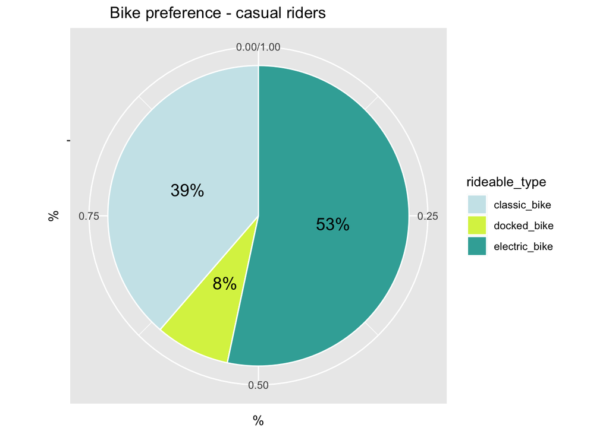

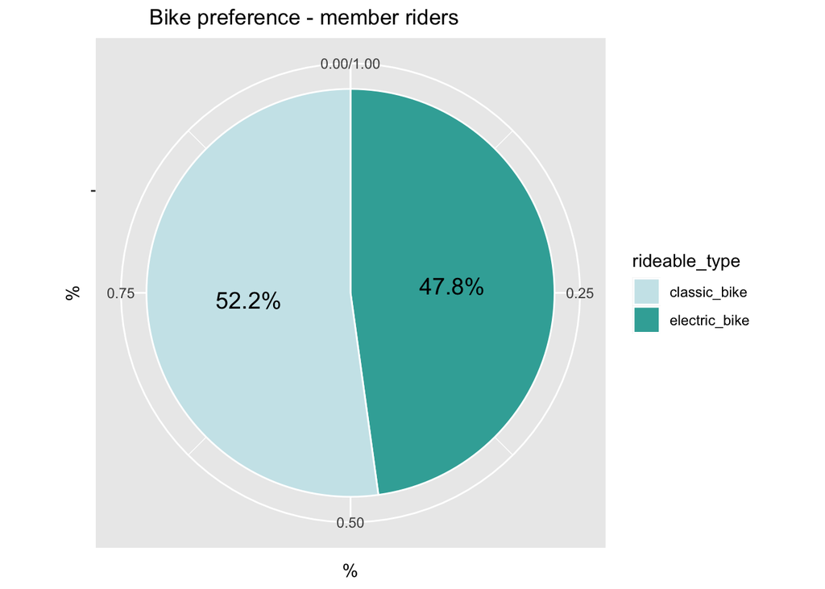

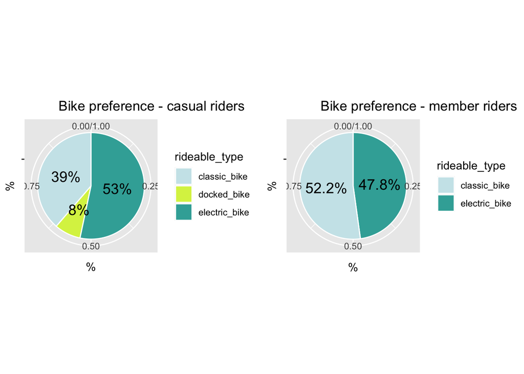

### 2. How is the service usage distributed over the week?

#### Order days of the week

Default is for Sunday to be the first day on R, I used the function factor to order the “day_of_week” column

```r
BikeTrips_todos_ordenado_por_dia<-BikeTrips_todos
BikeTrips_todos_ordenado_por_dia$day_of_week <- factor(BikeTrips_todos_ordenado_por_dia$day_of_week, c("Monday", "Tuesday", "Wednesday", "Thursday", "Friday", "Saturday", "Sunday"))
```

#### Counts the number of trips per day of the week

I’ve created a function called day. This function does the following:

1. Filters the “BikeTrips_todos_ordenado_por_dia” data frame by casual or member.
2. Sort and count the rides per day of the week (monday, tuesday, etc).
3. Creates a new column with the % calculations.
4. Scale the percentages in a new column called “labels” as characters to plot later on.

```r
day <- function(casual_or_member) {BikeTrips_todos_ordenado_por_dia %>%
  filter(member_casual == casual_or_member) %>%
  group_by(day_of_week) %>% # Variable to be transformed
  count(day_of_week)  %>%
  ungroup() %>%
  mutate(perc = n / sum(n)) %>%
  arrange(perc) %>%
  mutate(labels = scales::percent(perc)) }
```

#### Apply function and visualize tables

```r
day_casual <- day("casual")
day_member <- day("member")
day_casual
```

```
## # A tibble: 7 × 4
##   day_of_week      n  perc labels
##   <fct>        <int> <dbl> <chr>
## 1 Tuesday     255428 0.113 11.33%
## 2 Wednesday   259168 0.115 11.49%
## 3 Monday      263845 0.117 11.70%
## 4 Thursday    283164 0.126 12.56%
## 5 Friday      326462 0.145 14.48%
## 6 Sunday      387598 0.172 17.19%
## 7 Saturday    479560 0.213 21.26%
```

```r
day_member
```

```
## # A tibble: 7 × 4
##   day_of_week      n  perc labels
##   <fct>        <int> <dbl> <chr>
## 1 Sunday      381771 0.117 11.66%
## 2 Saturday    444170 0.136 13.57%
## 3 Monday      456314 0.139 13.94%
## 4 Friday      465679 0.142 14.23%
## 5 Thursday    501276 0.153 15.32%
## 6 Wednesday   509373 0.156 15.56%
## 7 Tuesday     514428 0.157 15.72%
```

#### Bar and pie chart visualizations

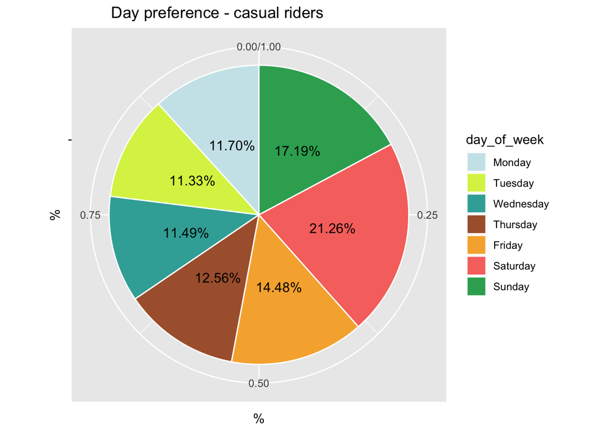

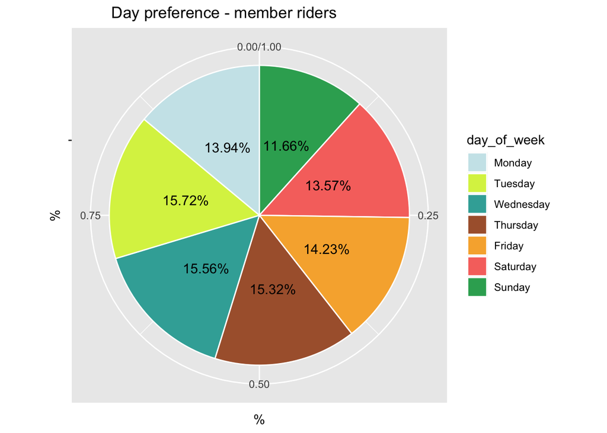

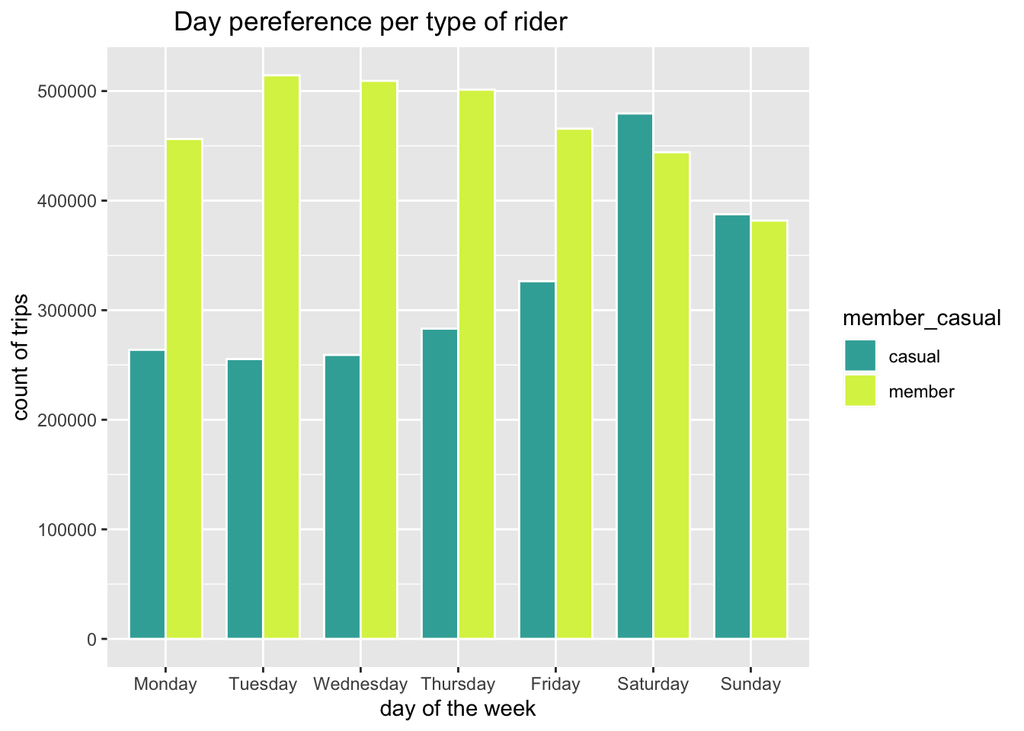

## 3. How is the service usage distributed over a day?

#### Counts the number of trips per time second by second

I’ve created a function called “calculate_bike_trip_counts”. This function does the following:

1. The if statement checks if member_type is provided. If it is, the function filters data to only include rows where the member_casual column matches member_type. If it isn’t provided, all rows are included.
2. The function then groups the rows of the data data frame by started_time column and counts the number of occurrences of each unique value in the started_time column, sorted in descending order. The result is a new data frame trip_counts that shows the count of bike trips for each unique started_time value.
3. Finally, the function returns the trip_counts data frame.

```r
calculate_bike_trip_counts <- function(data, member_type = NULL) {
  if (!is.null(member_type)) {
    data <- data %>% filter(member_casual == member_type)
  }
  trip_counts <- data %>%
    group_by(started_time) %>%
    count(started_time, sort = TRUE)
  return(trip_counts)
}
```

#### Apply function

```r
Tiempo_conteo <- calculate_bike_trip_counts(BikeTrips_todos, NULL)
Tiempo_conteo_casual <- calculate_bike_trip_counts(BikeTrips_todos, "casual")
Tiempo_conteo_member <- calculate_bike_trip_counts(BikeTrips_todos, "member")
```

#### Convert time to POSIXct for plotting

I’ve created a function called “convert_and_adjust_time”. This function does the following:

1. Takes a data frame and converts the started_time column to POSIXct format
2. Adjusts any values less than the Unix epoch time to be one day ahead.

```r
convert_and_adjust_time <- function(df) {
  df %>%
    mutate(started_time = as.POSIXct(started_time),
           started_time = if_else(started_time < as.POSIXct('1970-01-01 00:00:00', 'UTC'), started_time + 86400, started_time))
}
```

#### Apply function

```r
Tiempo_conteo2 <- convert_and_adjust_time(Tiempo_conteo)
Tiempo_conteo_casual2 <- convert_and_adjust_time(Tiempo_conteo_casual)
Tiempo_conteo_member2 <- convert_and_adjust_time(Tiempo_conteo_member)
```

#### Dot plot visualization

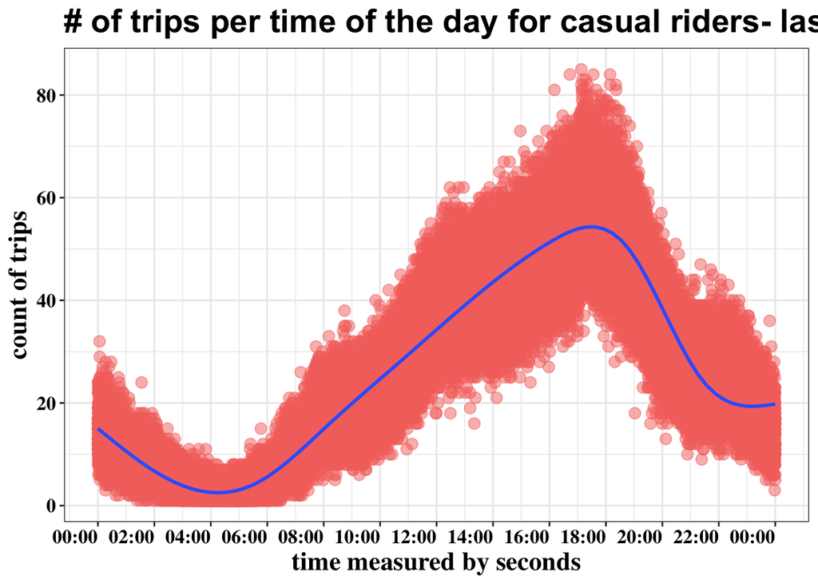

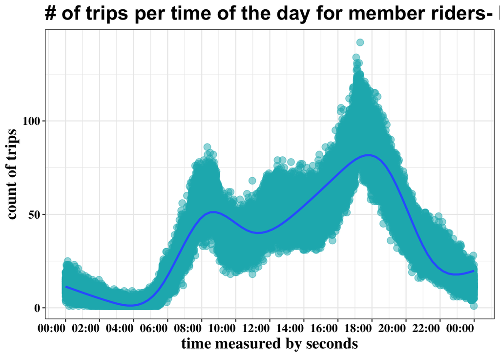

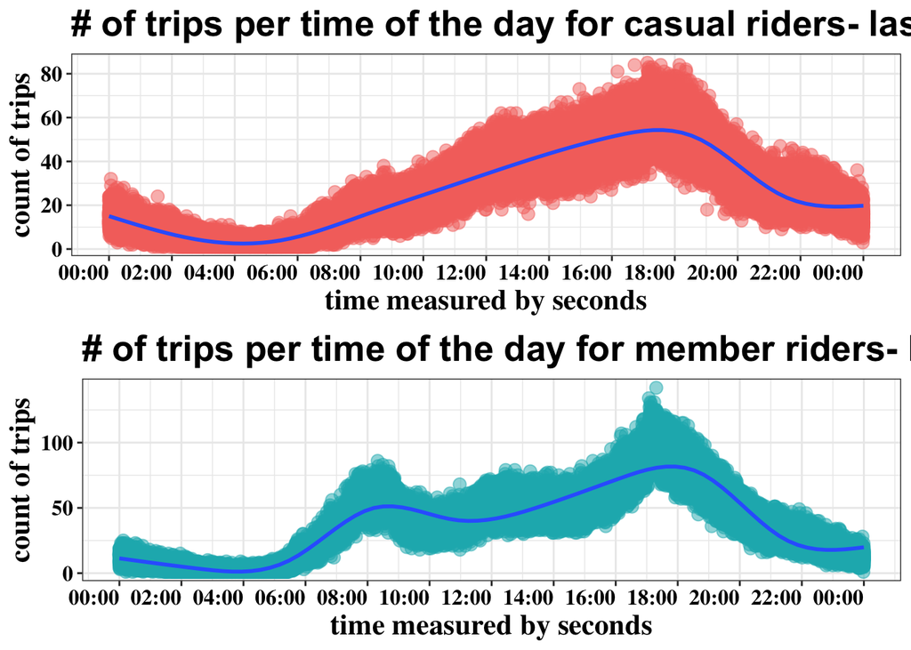

## 4. What is the average trip duration?

#### Convert time to POSIXct for plotting

I’ve created a function called “calculate_ride_length”. This function does the following:

1. Takes in a data frame data and an optional argument member_type. The if statement checks if member_type is provided. If it is, the function filters data to only include rows where the member_casual column matches member_type. If it isn’t provided, all rows are included.
2. The function then modifies the ride_length column of the data data frame by converting it to POSIXct format and adding 86400 seconds (one day) if the ride_length is less than 1970-01-01 00:00:00 in UTC time. This is done using the mutate and if_else functions from dplyr.
3. Finally, the function returns the modified data data frame.

```r
calculate_ride_length <- function(data, member_type = NULL) {
  if (!is.null(member_type)) {
    data <- data %>% filter(member_casual == member_type)
  }
  data <- data %>% mutate(
    ride_length = as.POSIXct(ride_length),
    ride_length = if_else(ride_length < as.POSIXct('1970-01-01 00:00:00', 'UTC'), ride_length + 86400, ride_length)
  )
  return(data)
}
```

```r
BikeTrips_todos_casual <- calculate_ride_length(BikeTrips_todos, "casual")

BikeTrips_todos_member <- calculate_ride_length(BikeTrips_todos, "member")
```

#### Calculate mean and median for casual and member riders

```r
# I calculated the mean for casual riders and convert it into a numeric value
mean1 <- BikeTrips_todos_casual %>%
   summarize(mean(ride_length))

mean1_numeric <- as.numeric(mean1)
mean1
```

```
## # A tibble: 1 × 1
##   `mean(ride_length)`
##   <dttm>
## 1 1970-01-01 00:22:51
```

```r
# I calculated the median for casual riders and convert it into a numeric value
median_casual <- BikeTrips_todos_casual %>%
  summarize(median(ride_length))

median1_numeric <- as.numeric(median_casual)
median_casual
```

```
## # A tibble: 1 × 1
##   `median(ride_length)`
##   <dttm>
## 1 1970-01-01 00:13:23
```

```r
# I calculated the mean for member riders and convert it into a numeric value
mean2 <- BikeTrips_todos_member %>%
  summarize(mean(ride_length))

mean2_numeric <- as.numeric(mean2)
mean2
```

```
## # A tibble: 1 × 1
##   `mean(ride_length)`
##   <dttm>
## 1 1970-01-01 00:12:26
```

```r
# I calculated the median for casual riders and convert it into a numeric value
median_member <- BikeTrips_todos_member %>%
  summarize(median(ride_length))

median2_numeric <- as.numeric(median_member)
median_member
```

```
## # A tibble: 1 × 1
##   `median(ride_length)`
##   <dttm>
## 1 1970-01-01 00:08:50
```

#### Create 2 vertical lines with the mean for plotting

```r
mean1_vertical <- data.frame(x=c(mean1_numeric,mean1_numeric), y=c(-5,5))

mean2_vertical <- data.frame(x=c(mean2_numeric,mean2_numeric), y=c(-5,5))
```

#### Histogram visualizations

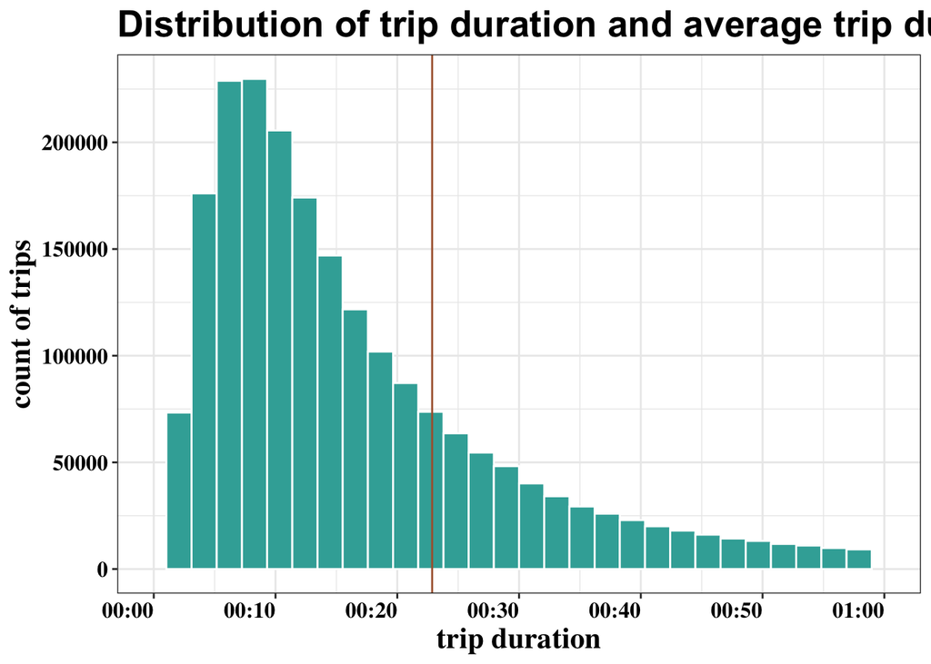

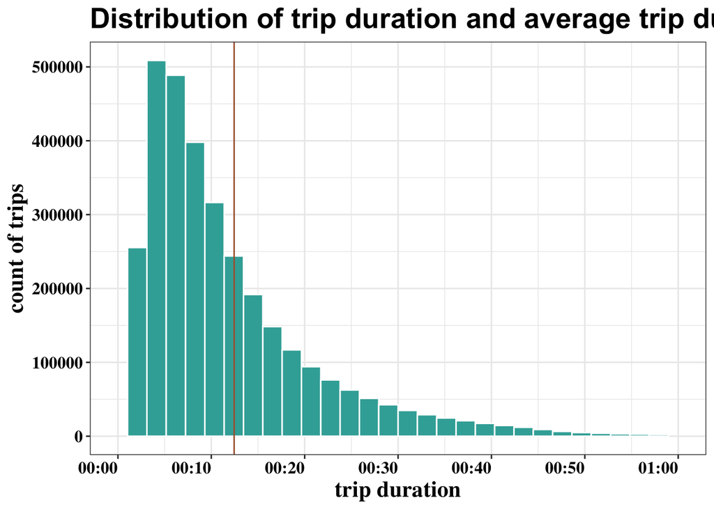

### 5. What is the preferred station for starting trips?

#### Top ten start stations for member and casual riders

```r
# I printed the top ten start stations for member riders
start_station_member <- BikeTrips_todos %>%
  filter(member_casual == "member") %>%
  count(start_station_name, sort = TRUE)

start_station_member %>%
print(n=11 )
```

```
## # A tibble: 1,410 × 2
##    start_station_name                n
##    <chr>                         <int>
##  1 start_station_none_given     503428
##  2 Kingsbury St & Kinzie St      25146
##  3 Clark St & Elm St             22147
##  4 Wells St & Concord Ln         21459
##  5 Ellis Ave & 60th St           19715
##  6 University Ave & 57th St      19551
##  7 Clinton St & Washington Blvd  19022
##  8 Clinton St & Madison St       18898
##  9 Wells St & Elm St             18851
## 10 Loomis St & Lexington St      17848
## 11 Dearborn St & Erie St         17090
## # … with 1,399 more rows
```

```r
# I printed the top ten start stations for casual riders
start_station_casual <- BikeTrips_todos %>%
  filter(member_casual == "casual") %>%
  count(start_station_name, sort = TRUE)

  start_station_casual %>%
  print(n=11 )
```

```
## # A tibble: 1,515 × 2
##    start_station_name                      n
##    <chr>                               <int>
##  1 start_station_none_given           356308
##  2 Streeter Dr & Grand Ave             54791
##  3 DuSable Lake Shore Dr & Monroe St   30394
##  4 Millennium Park                     25548
##  5 Michigan Ave & Oak St               23580
##  6 DuSable Lake Shore Dr & North Blvd  21750
##  7 Shedd Aquarium                      19405
##  8 Theater on the Lake                 17293
##  9 Wells St & Concord Ln               15832
## 10 Clark St & Armitage Ave             13450
## 11 Dusable Harbor                      13335
## # … with 1,504 more rows
```

#### Top ten end stations for member and casual riders

```r
 # I printed the top ten end stations for casual riders

end_station_casual <- BikeTrips_todos %>%
  filter(member_casual == "casual") %>%
  count(end_station_name, sort = TRUE)

end_station_casual %>%
print(n = 11)
```

```
## # A tibble: 1,529 × 2
##    end_station_name                        n
##    <chr>                               <int>
##  1 end_station_none_given             418061
##  2 Streeter Dr & Grand Ave             56605
##  3 DuSable Lake Shore Dr & Monroe St   27989
##  4 Millennium Park                     26597
##  5 Michigan Ave & Oak St               24831
##  6 DuSable Lake Shore Dr & North Blvd  23965
##  7 Theater on the Lake                 18217
##  8 Shedd Aquarium                      17902
##  9 Wells St & Concord Ln               15152
## 10 Clark St & Armitage Ave             13414
## 11 Clark St & Lincoln Ave              13089
## # … with 1,518 more rows
```

```r
# I printed the top ten end stations for member riders
end_station_member <- BikeTrips_todos %>%
  filter(member_casual == "member") %>%
  count(end_station_name, sort = TRUE)


end_station_member %>%
  print(n = 11)
```

```
## # A tibble: 1,397 × 2
##    end_station_name                  n
##    <chr>                         <int>
##  1 end_station_none_given       501666
##  2 Kingsbury St & Kinzie St      24630
##  3 Clark St & Elm St             22474
##  4 Wells St & Concord Ln         21983
##  5 University Ave & 57th St      20360
##  6 Clinton St & Washington Blvd  19671
##  7 Clinton St & Madison St       19532
##  8 Ellis Ave & 60th St           19230
##  9 Wells St & Elm St             18625
## 10 Broadway & Barry Ave          17627
## 11 Loomis St & Lexington St      17351
## # … with 1,386 more rows
```

### 6. How are the trip start points distributed geographically?

#### Range of starting latitude of trips

```r
max(BikeTrips_todos$start_lat)
```

```
## [1] 45.63503
```

```r
min(BikeTrips_todos$start_lat)
```

```
## [1] 41.64
```

#### Histogram visualization of starting latitude of trips

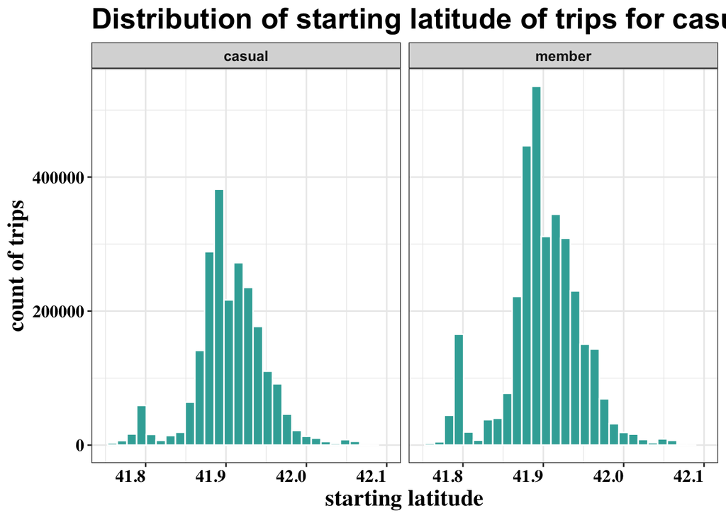

#### Range of starting longitude of trips

```r
max(BikeTrips_todos$start_lng)
```

```
## [1] -73.79648
```

```r
min(BikeTrips_todos$start_lng)
```

```
## [1] -87.84
```

#### Histogram visualization of starting longitude of trips

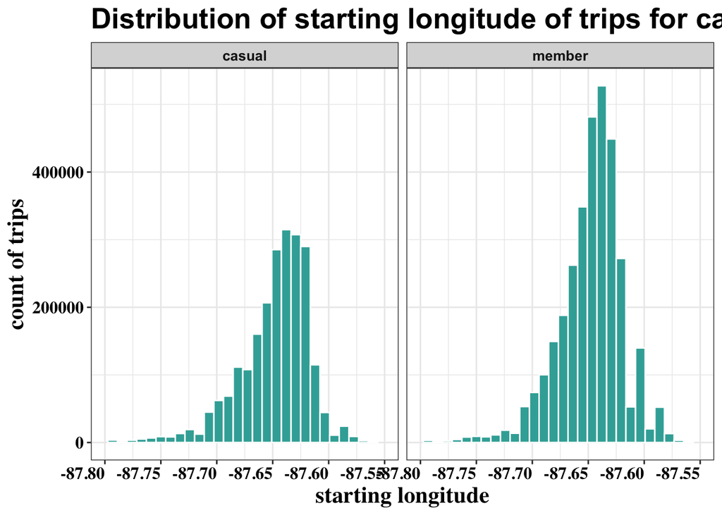

#### Range of ending latitude of trips

```r
max(BikeTrips_todos$end_lat)
```

```
## [1] 91
```

```r
min(BikeTrips_todos$end_lat)
```

```
## [1] 41.39
```

#### Histogram visualization of ending latitude of trips

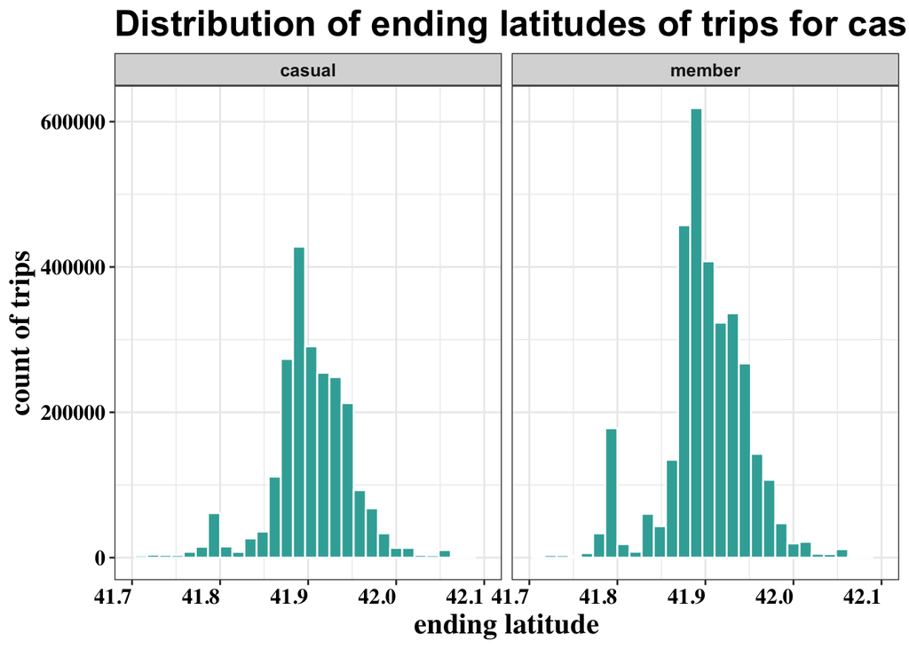

#### Range of ending longitude of trips

```r
max(BikeTrips_todos$end_lng)
```

```
## [1] 181
```

```r
min(BikeTrips_todos$end_lng)
```

```
## [1] -88.97
```

#### Histogram visualization of ending longitude of trips

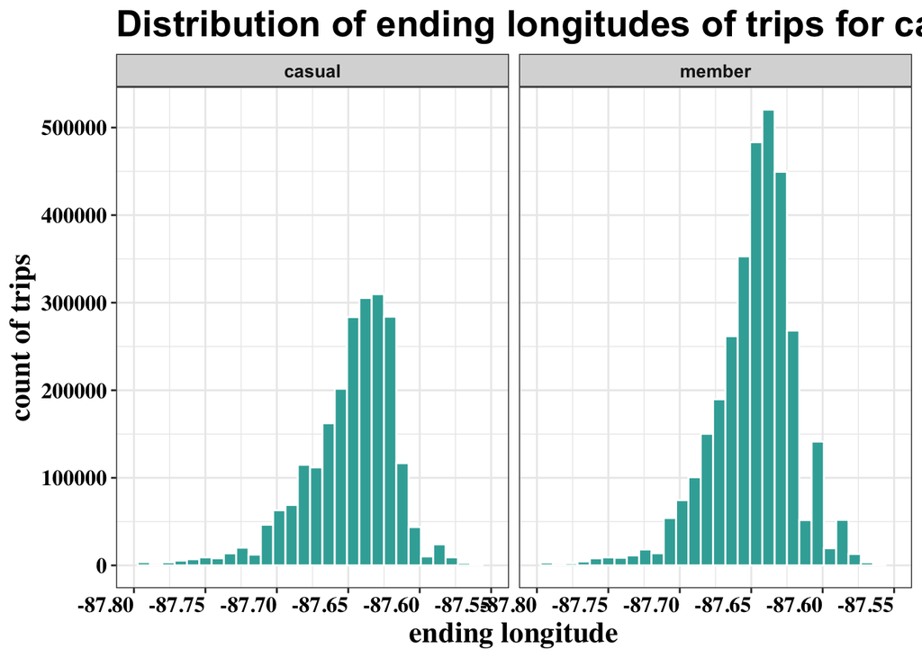